# Reproducible Research: Peer Assessment 1

```r
options(scipen = 1, digits = 2)
```

## Loading and preprocessing the data

```r
activity <- read.csv("activity.csv")
```

Process/transform the data (if necessary) into a format suitable for your analysis

```r
activity$date <- as.Date(activity$date)
```

## What is mean total number of steps taken per day?

For this part of the assignment, you can ignore the missing values in the dataset.

Calculate the total number of steps taken per day

```r
stepStats <- aggregate(cbind("sumDailySteps" = steps) ~ date, data = activity, function(x) sum(x,na.rm = TRUE))
meanDailySteps <- round(mean(stepStats$sumDailySteps),3)
medianDailySteps <- median(stepStats$sumDailySteps)
```

Make a histogram of the total number of steps taken each day

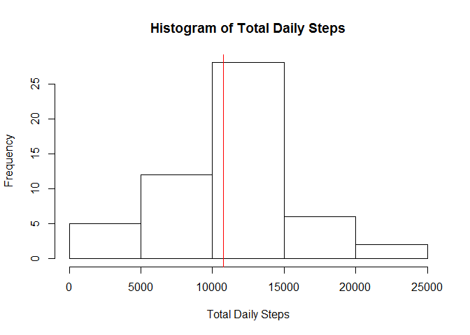

```r
hist(stepStats$sumDailySteps, main="Histogram of Total Daily Steps", xlab="Total Daily Steps")

# Mean - Red Line
abline(v=meanDailySteps, col='red', lwd=1)
```

Calculate and report the mean and median of the total number of steps taken per day

```r
print(paste("Mean Daily Steps :", as.character(meanDailySteps)))
```

```
## [1] "Mean Daily Steps : 10766.189"
```

```r
print(paste("Median Daily Steps :", as.character(medianDailySteps)))
```

```
## [1] "Median Daily Steps : 10765"
```

## What is the average daily activity pattern?

Make a time series plot (i.e. type = “l”) of the 5-minute interval (x-axis) and the average number of steps taken, averaged across all days (y-axis)

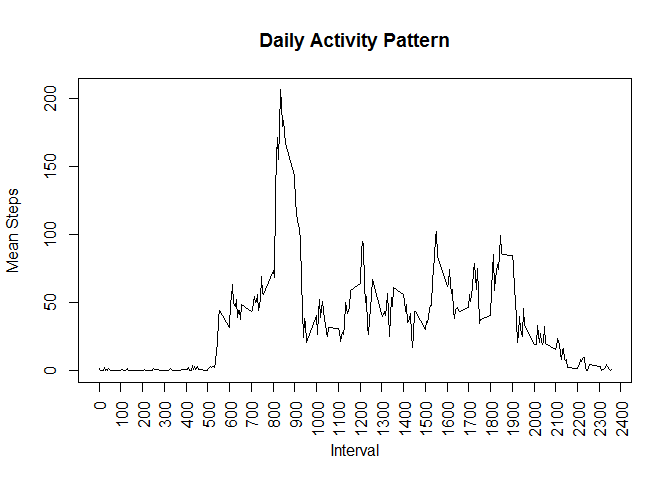

```r
library(plyr)
intervalMeanSummary <- ddply(activity, .(interval), summarize, mean = mean(steps, na.rm=TRUE))

plot(intervalMeanSummary, type="l", xlab="Interval", ylab="Mean Steps", main="Daily Activity Pattern", col=1, xaxt="n")
axis(1, at = seq(0, 3000, by = 100), las=2)
```

Which 5-minute interval, on average across all the days in the dataset, contains the maximum number of steps?

```r
maxInterval <- intervalMeanSummary[which.max(intervalMeanSummary$mean),]
print(maxInterval)
```

```
##     interval mean
## 104      835  206
```